A PREPRINT • AUGUST 2026

# Analisis Satelit (GSMaP & GPM IMERG), Reanalisis ERA5, dan Sensor AWS IoT Jerukagung: Evaluasi Multimetrik Error (MBE, RMSE, MAE), Korelasi Pearson & Spearman, dan Karakteristik Iklim 20 Tahun

**Tim Peneliti Presipitasi & AI Kebumen** • Laboratorium Kecerdasan Buatan Terapan & Sains Atmosfer Geospasial  
*Wilayah Studi: Stasiun Jerukagung, Kabupaten Kebumen, Jawa Tengah (Periode Sinkron: 1 Januari 2025 s.d. 31 Mei 2026 / 12.384 Jam)*

### Ringkasan Eksekutif • Abstract

Laporan ini menyajikan evaluasi hidrometeorologi komprehensif perbandingan data curah hujan dan variabel meteorologi permukaan antara produk satelit (JAXA GSMaP, NASA GPM IMERG), reanalisis ECMWF ERA5, serta stasiun pengamatan otomatis AWS IoT Jerukagung, Kebumen (periode sinkron 1 Januari 2025 s.d. 31 Mei 2026 / 12.384 jam) serta rekonstruksi iklim 20 tahun (2005–2025). Evaluasi mencakup analisis scatter plot, matriks korelasi linier Pearson (r) dan rank non-parametrik Spearman (ρ) dengan tata letak simetris, evaluasi multimetrik error (Mean Bias Error / MBE, Root Mean Square Error / RMSE, Mean Absolute Error / MAE), ambang batas kejadian hujan (0.2 mm/jam), time series fluktuasi bulanan, korelasi 13 fitur fisik atmosferik ERA5 untuk Deep Learning Pre-Training, serta analisis klimatologi dan diagram kotak (boxplot) variabilitas musiman 20 tahun.

**Keywords:** Korelasi Pearson, Korelasi Spearman, Mean Bias Error (MBE), Root Mean Square Error (RMSE), Mean Absolute Error (MAE), JAXA GSMaP, NASA GPM IMERG, ECMWF ERA5 Hourly, AWS IoT Jerukagung.

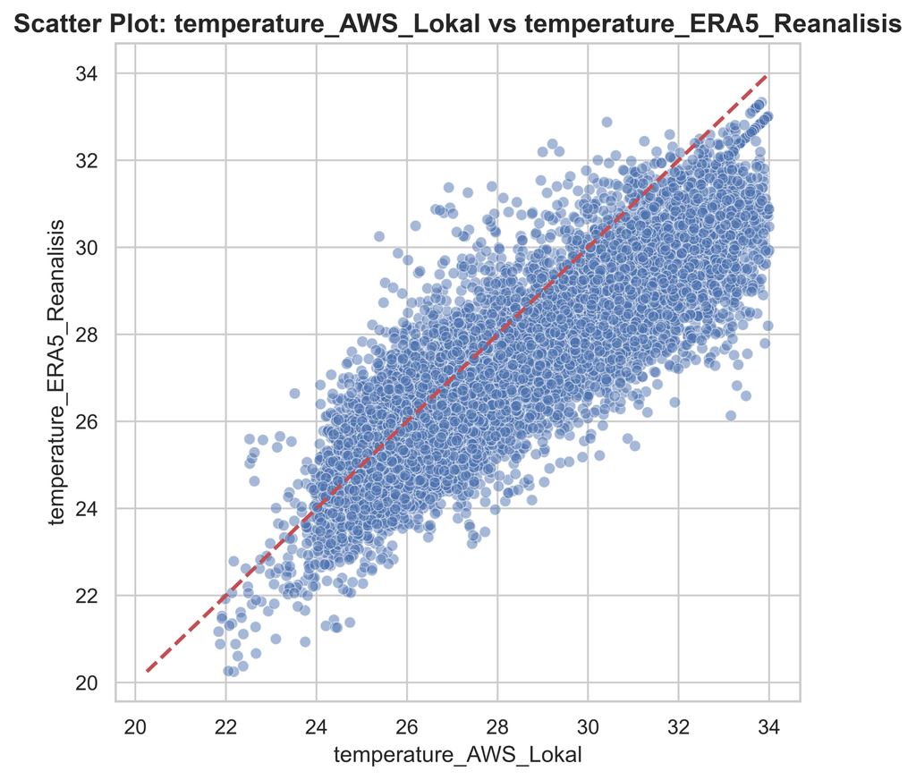

Gambar 1: Scatter Plot Suhu Udara (AWS IoT vs ERA5 Reanalisis)

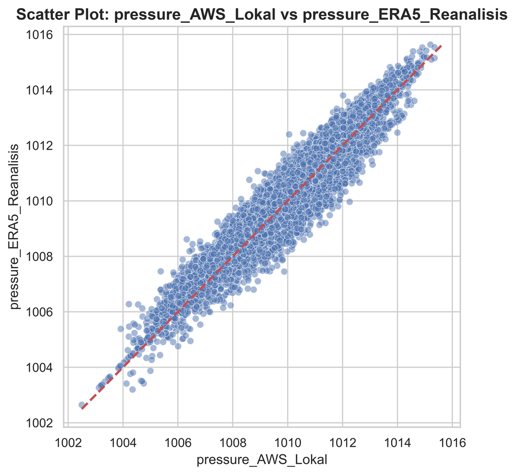

Gambar 2: Scatter Plot Tekanan Permukaan (AWS IoT vs ERA5 Reanalisis)

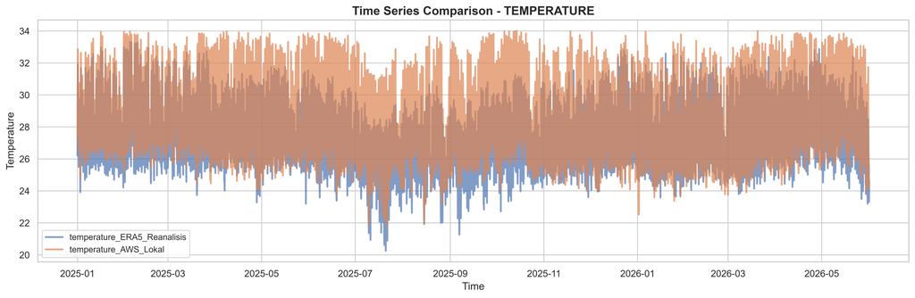

Gambar 3: Time Series Suhu Udara Permukaan

[figure not shown]

Gambar 4: Scatter Plot Matrix Curah Hujan Jam-jaman

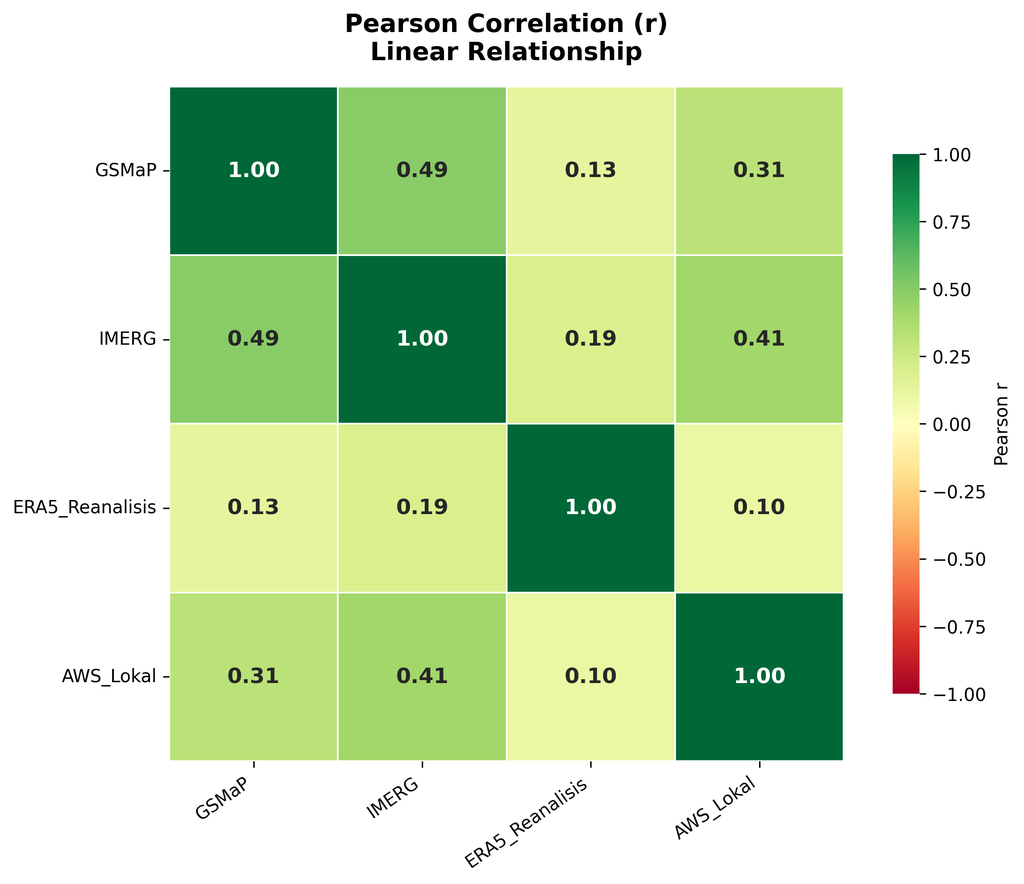

Gambar 5: Heatmap Korelasi Pearson Curah Hujan (Urutan: GSMaP, IMERG, ERA5, AWS)

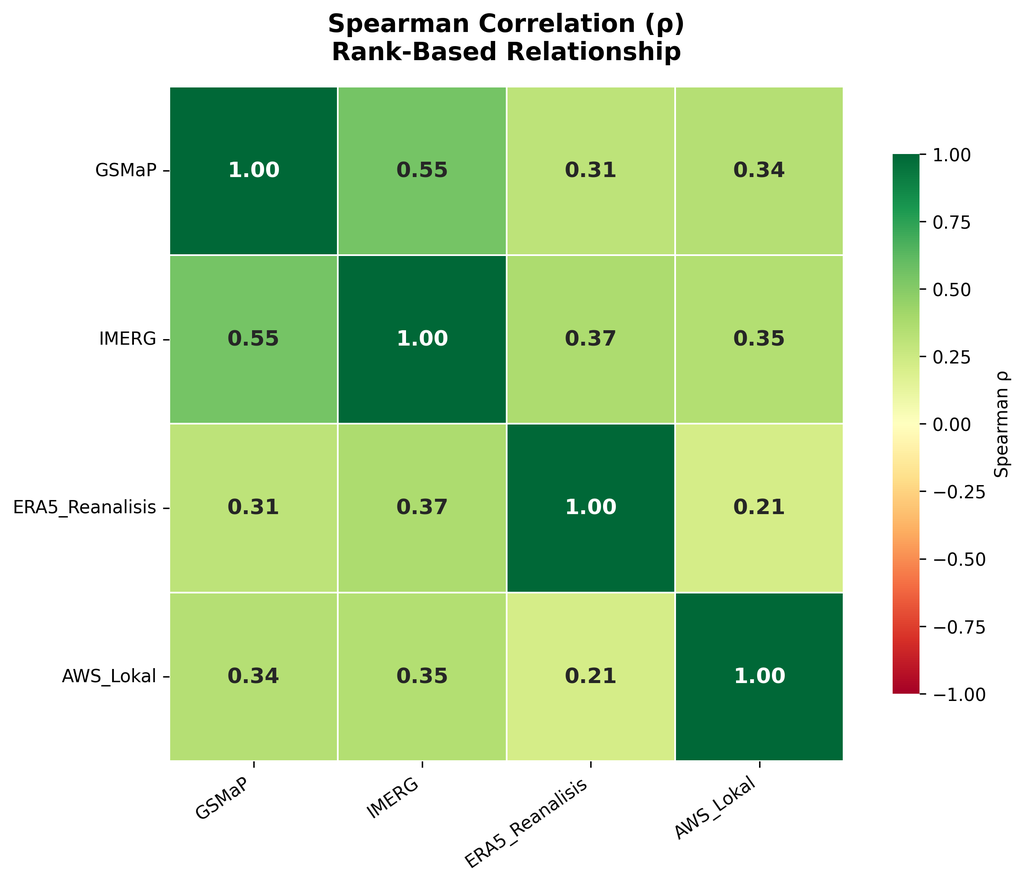

Gambar 6: Heatmap Korelasi Spearman Curah Hujan (Urutan: GSMaP, IMERG, ERA5, AWS)

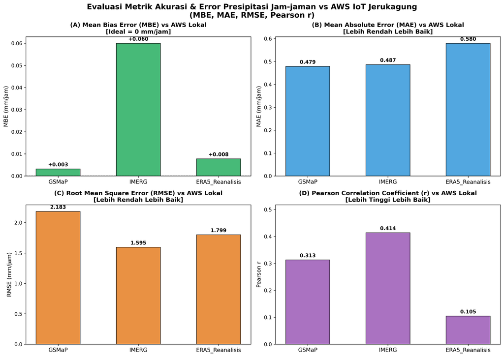

Gambar 7: Evaluasi Multimetrik Error Presipitasi Jam-jaman (MBE, MAE, RMSE, Pearson r) vs AWS IoT

[figure not shown]

Gambar 8: Ringkasan Korelasi Pearson Antar Sumber Data Curah Hujan

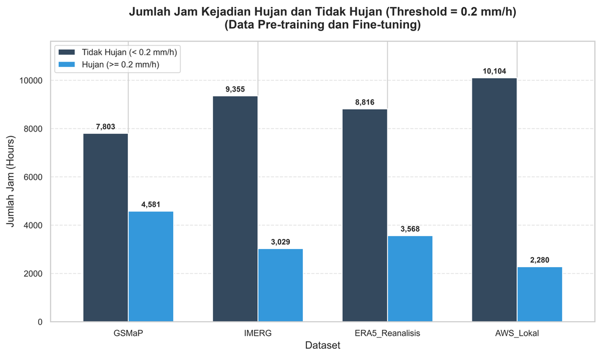

Gambar 9: Jumlah Jam Kejadian Hujan vs Tidak Hujan (Threshold 0.2 mm/h)

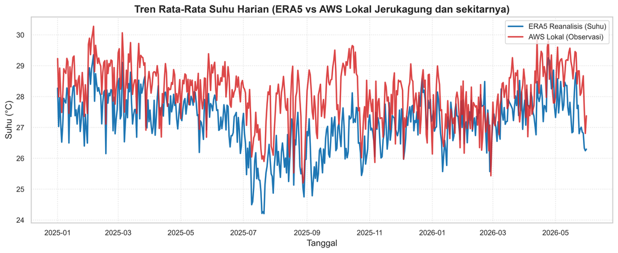

Gambar 10: Tren Rata-Rata Suhu Harian (ERA5 vs AWS IoT)

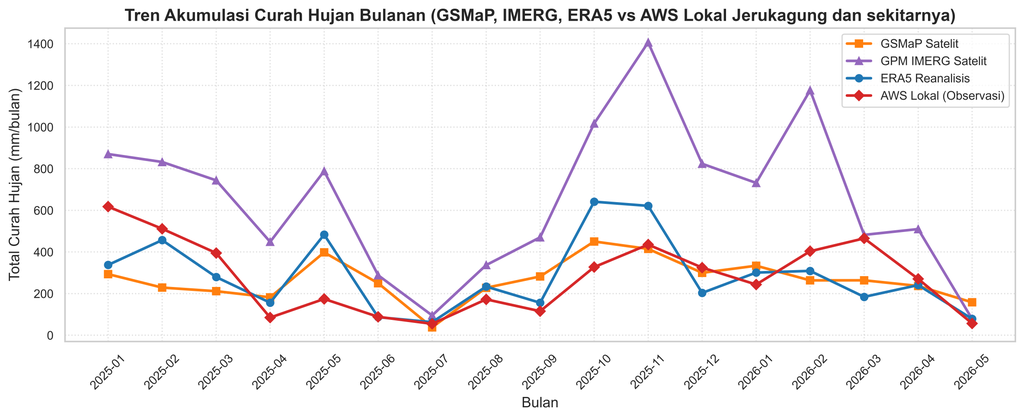

Gambar 11: Tren Akumulasi Curah Hujan Bulanan

[figure not shown]

Gambar 12: Matriks Korelasi Pearson Fitur Pre-Training ERA5

[figure not shown]

Gambar 13: Matriks Korelasi Spearman Fitur Pre-Training ERA5

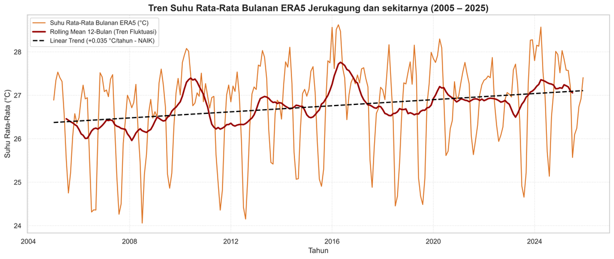

Gambar 14: Tren Suhu Rata-Rata Bulanan ERA5 (2005–2025)

[figure not shown]

Gambar 15: Tren Curah Hujan Bulanan Jangka Panjang (2005–2025)

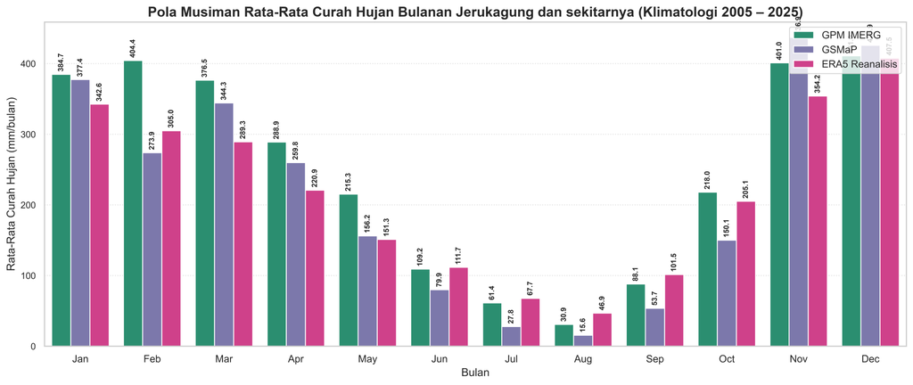

Gambar 16: Pola Musiman Rata-Rata Curah Hujan Bulanan (Klimatologi 2005–2025)

[figure not shown]

Gambar 17: Diagram Kotak (Boxplot) Variabilitas Curah Hujan Bulanan (2005–2025)

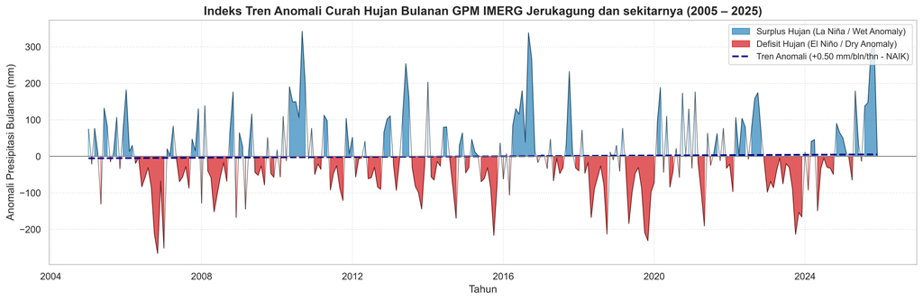

Gambar 18: Grafik Tren Anomali Curah Hujan Bulanan GPM IMERG (2005–2025)